# University of Illinois - Urbana-Champaign

# 1 RQ: What are the characteristics of student list purchases?

### 1.0.1 OOS Order Category: By MSA

3 of the 21 OOS orders were by MSA

- 2 orders in 2019
- 1 order in 2020

They made **2** “OOS Regional MSA” orders **1** “Regional Counselor MSAs” order.

- They used the segment analysis from above
- A+/B- high school GPA
- MSAs from states: CA, TX, GA, FL, NY, NJ

[interactive chart not shown]

# 2 RQ: What are the characteristics of schools/communities included vs. not included in purchased lists

General observations

- Of 121,110 students purchased between 2017-2020, 52,788 reside in California. About 44% of student purchased (*assuming students weren’t purchased more than once).
- Of 52,788 students purchased in California, 19,071 were purchased in the LA metro area alone (36%).

## 2.1 Zip code investigations

After merging CEEB and NCES data, there were 45,172 students purchased in California, 18,417 had zip codes that did not match the zip code for the high school they attended. Perhaps wehave zip codes of the home addresses of students purchased?

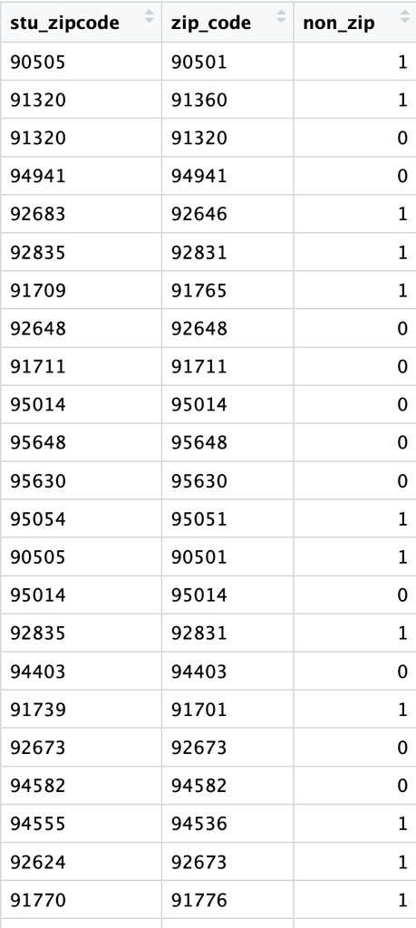

- If we use zip code of students’ households, then we can get more precise information about them at the zip code-level (e.g., median household income, race/ethnicity, education level).
- If we use zip code of the high school, we can use secondary high school data about performance and racial/ethnic composition of the high school.
- Perhaps we could use both?

## 2.2 Out-of-State, zip codes purchased in LA metro area vs. not purchased

[interactive chart not shown]

- If we select on the Number of students purchased button, we can see that more students are visted in zip codes with a smaller percentage of Black, Latinx, and Native American population and zip codes with overall higher median household income.
- Notice that areas shaded in gray (NA) are zip codes where no students were purchased (~68 zip codes). Similarly, these zip codes tend to be home to more Black, Latinx, and Native American people and have a lower median household income.